# LAs_clusters

09 December, 2020, 10:23

## Distance to Metro Area

```r
# get LA
# (i) directly from the web
#la <- readOGR("http://geoportal1-ons.opendata.arcgis.com/datasets/b6d2e15801de45328b760a4f55d74318_0.geojson?outSR={%22latestWkid%22:3857,%22wkid%22:102100}")#, layer="OGRGeoJSON")
# or, (ii) from the json I saved locally
path.json <- paste(path, "./data/raw/Local_Authority_Districts_(April_2019)_Boundaries_UK_BFE.geojson", sep = "")
la <- readOGR(path.json)#, layer="OGRGeoJSON")
# source: https://data.gov.uk/dataset/7c387c64-d25f-474a-b07e-b933578caea2/local-authority-districts-april-2019-boundaries-uk-bfe

# spatial transformations
la <- spTransform(la, CRS("+init=epsg:4326"))
la@data$LAD19NM <- as.character(la@data$LAD19NM)
ladDist <- la@data[,c("LAD19CD", "LAD19NM")]
names(ladDist)[1] <- "lad19cd"

#distance from London and other
coords_LAD <- la@data[,c("LONG", "LAT")]
London <- la[which(la@data$LAD19NM == "City of London"),]
London <- gCentroid(London)
distLondon <- distm(coords_LAD, London, fun=distCosine)
#result in meters - change to km
distLondon <- round((distLondon/1000),2)
Birmingham <- la[which(la@data$LAD19NM == "Birmingham"),]
Birmingham <- gCentroid(Birmingham)
distBham <- distm(coords_LAD, Birmingham, fun=distCosine)
distBham <- round((distBham/1000),2)
Manchester <- la[which(la@data$LAD19NM == "Manchester"),]
Manchester <- gCentroid(Manchester)
distManc <- distm(coords_LAD, Manchester, fun=distCosine)
distManc <- round((distManc/1000),2)
Leeds <- la[which(la@data$LAD19NM == "Leeds"),]
Leeds <- gCentroid(Leeds)
distLeeds <- distm(coords_LAD, Leeds, fun=distCosine)
distLeeds <- round((distLeeds/1000),2)
Liverpool <- la[which(la@data$LAD19NM == "Liverpool"),]
Liverpool <- gCentroid(Liverpool)
distLivp <- distm(coords_LAD, Liverpool, fun=distCosine)
distLivp <- round((distLivp/1000),2)
Newcastle <- la[which(la@data$LAD19NM == "Newcastle upon Tyne"),]
Newcastle <- gCentroid(Newcastle)
distNewc <- distm(coords_LAD, Newcastle, fun=distCosine)
distNewc <- round((distNewc/1000),2)
Sheffield <- la[which(la@data$LAD19NM == "Sheffield"),]
Sheffield <- gCentroid(Sheffield)
distShef <- distm(coords_LAD, Sheffield, fun=distCosine)
distShef <- round((distShef/1000),2)
SouthHants <- la[which(la@data$LAD19NM == "Fareham"),]
SouthHants <- gCentroid(SouthHants)
distSHam <- distm(coords_LAD, SouthHants, fun=distCosine)
distSHam <- round((distSHam/1000),2)
Nottingham <- la[which(la@data$LAD19NM == "Nottingham"),]
Nottingham <- gCentroid(Nottingham)
distNotts <- distm(coords_LAD, Nottingham, fun=distCosine)
distNotts <- round((distNotts/1000),2)
Bristol <- la[which(la@data$LAD19NM == "Bristol, City of"),]
Bristol <- gCentroid(Bristol)
distBris <- distm(coords_LAD, Bristol, fun=distCosine)
distBris <- round((distBris/1000),2)
Cardiff <- la[which(la@data$LAD19NM == "Cardiff"),]
Cardiff <- gCentroid(Cardiff)
distCard <- distm(coords_LAD, Cardiff, fun=distCosine)
distCard <- round((distCard/1000),2)
Glasgow <- la[which(la@data$LAD19NM == "Glasgow City"),]
Glasgow <- gCentroid(Glasgow)
distGlas <- distm(coords_LAD, Glasgow, fun=distCosine)
distGlas <- round((distGlas/1000),2)

ladDist <- cbind(ladDist, distLondon, distBham, distManc, distLeeds,
                 distLivp, distNewc, distShef, distSHam, distNotts,
                 distBris, distCard, distGlas)

ladDist$distMet <- apply(ladDist[,3:14], 1, min)
ladDist <- ladDist %>%
  dplyr::select(lad19cd, distLondon, distMet)


#test <- left_join(lad, ladDist)
```

## Job density 2018

```r
job.dens <- read_csv("https://www.nomisweb.co.uk/api/v01/dataset/NM_57_1.data.csv?geography=1816133633...1816133848,1820327937...1820328318&date=latest&item=3&measures=20100")
job.dens <- job.dens %>%
  dplyr::select(GEOGRAPHY_CODE, GEOGRAPHY_NAME, OBS_VALUE) %>%
  rename(job.dens2018 = OBS_VALUE) %>%
  rename(lad19cd = GEOGRAPHY_CODE) %>%
  distinct()

# test <- left_join(lad, job.dens, by = "lad19cd")
```

## Population 2018

```r
# pop <- read_csv("https://www.nomisweb.co.uk/api/v01/dataset/NM_31_1.data.csv?geography=1807745025...1807745028,1807745030...1807745032,1807745034...1807745155,1807745157...1807745164,1807745166...1807745170,1807745172...1807745177,1807745179...1807745194,1807745196,1807745197,1807745199,1807745201...1807745218,1807745221,1807745222,1807745224,1807745226...1807745231,1807745233,1807745234,1807745236...1807745244,1807745271...1807745281,1811939329...1811939332,1811939334...1811939336,1811939338...1811939497,1811939499...1811939501,1811939503,1811939505...1811939507,1811939509...1811939517,1811939519,1811939520,1811939524...1811939570,1811939575...1811939599,1811939601...1811939628,1811939630...1811939634,1811939636...1811939647,1811939649,1811939655...1811939664,1811939667...1811939680,1811939682,1811939683,1811939685,1811939687...1811939704,1811939707,1811939708,1811939710,1811939712...1811939717,1811939719,1811939720,1811939722...1811939730,1811939757...1811939767&date=latestMINUS1-latest&sex=7&age=0,22&measures=20100")

pop <- read_csv("https://www.nomisweb.co.uk/api/v01/dataset/NM_31_1.data.csv?geography=1820327937...1820328318,1816133633...1816133848&date=latestMINUS1-latest&sex=7&age=0,22&measures=20100")
pop <- pop %>%
  dplyr::select(GEOGRAPHY_CODE, GEOGRAPHY_NAME, AGE_NAME, OBS_VALUE) %>%
  distinct(GEOGRAPHY_CODE, AGE_NAME, .keep_all = T) %>%
  spread(AGE_NAME, OBS_VALUE) %>%
  rename(pop16_64 = `Aged 16 - 64`) %>%
  rename(pop = `All ages`) %>%
  rename(lad19cd = GEOGRAPHY_CODE)

# test <- left_join(lad, pop, by = "lad19cd")
# sapply(test, function(x) sum(is.na(x)))
```

## Population density 2018

```r
# this is just population
pop.dens <- read_csv("https://www.nomisweb.co.uk/api/v01/dataset/NM_31_1.data.csv?geography=1820327937...1820328318,1816133633...1816133848&date=latestMINUS1-latest&sex=7&age=0,22&measures=20100")
pop.dens <- pop.dens %>%
  dplyr::select(GEOGRAPHY_CODE, GEOGRAPHY_NAME, AGE_NAME, OBS_VALUE) %>%
  distinct(GEOGRAPHY_CODE, AGE_NAME, .keep_all = T) %>%
  spread(AGE_NAME, OBS_VALUE) %>%
  rename(pop16_64 = `Aged 16 - 64`) %>%
  rename(pop = `All ages`) %>%
  rename(lad19cd = GEOGRAPHY_CODE) %>%
  dplyr::select(-pop16_64)

crs(la)
```

```
## CRS arguments: +proj=longlat +datum=WGS84 +no_defs
```

```r
la$area_sqkm <- area(la) / 1000000

pop.dens <- merge(pop.dens, la@data, by.x = "lad19cd", by.y = "LAD19CD", all.x = T)

pop.dens <- pop.dens %>%
  mutate(pop.dens = pop/area_sqkm) %>%
  dplyr::select(lad19cd,pop.dens)

# sapply(pop.dens, function(x) sum(is.na(x)))
# test <- pop.dens[is.na(pop.dens$area_sqkm),]
```

## N/S divide

```r
# It only includes only the south

ns <- read_csv("https://opendata.arcgis.com/datasets/3ba3daf9278f47daba0f561889c3521a_0.csv") %>%
  mutate(south = ifelse(RGN19NM=="London" |
                        RGN19NM=="South West" |
                        RGN19NM=="East of England" |
                        RGN19NM=="South East", 1, 0)) %>%
  dplyr::select(LAD19CD, south) %>%
  dplyr::filter(south==1) %>%
  rename(lad19cd = LAD19CD)
```

## Labour supply March 2020

```r
labour <- read_csv("https://www.nomisweb.co.uk/api/v01/dataset/NM_17_5.data.csv?geography=1816133633...1816133837,1820327937...1820328307&date=latest&variable=18,1532...1540,290,720&measures=20599,21001,21002,21003")
labour <- labour %>%
  dplyr::select(GEOGRAPHY_CODE, GEOGRAPHY_NAME, VARIABLE_NAME, OBS_VALUE) %>%
  distinct(GEOGRAPHY_CODE, VARIABLE_NAME, .keep_all = T) %>%
  spread(VARIABLE_NAME, OBS_VALUE) %>%
  rename(lad19cd = GEOGRAPHY_CODE) %>%
  rename(managers =  `% all in employment who are - 1: managers, directors and senior officials (SOC2010)`) %>%
  rename(prof = `% all in employment who are - 2: professional occupations (SOC2010)`) %>%
  rename(tech = `% all in employment who are - 3: associate prof & tech occupations (SOC2010)`) %>%
  rename(admin = `% all in employment who are - 4: administrative and secretarial occupations (SOC2010)`) %>%
  rename(skilled = `% all in employment who are - 5: skilled trades occupations (SOC2010)`) %>%
  rename(caring = `% all in employment who are - 6: caring, leisure and other service occupations (SOC2010)`) %>%
  rename(sales = `% all in employment who are - 7: sales and customer service occupations (SOC2010)`) %>%
  rename(plant = `% all in employment who are - 8: process, plant and machine operatives (SOC2010)`) %>%
  rename(elementary = `% all in employment who are - 9: elementary occupations (SOC2010)`) %>%
  rename(NVQ3 = `% with NVQ3+ - aged 16-64`) %>%
  rename(NVQ4 = `% with NVQ4+ - aged 16-64`) %>%
  rename(econ.act = `Economic activity rate - aged 16-64`) %>% # No NVQ data here as this is for Jul 2019-Jun 2020. NVQ is only
  dplyr::select(-NVQ3, -NVQ4)                                  # available for Dec - Dec. I download these data seperetely.

# test <- left_join(lad, labour, by = "lad19cd")
# sapply(test, function(x) sum(is.na(x)))
```

```r
nvq4 <- read_csv("https://www.nomisweb.co.uk/api/v01/dataset/NM_17_5.data.csv?geography=1811939329...1811939332,1811939334...1811939336,1811939338...1811939497,1811939499...1811939501,1811939503,1811939505...1811939507,1811939509...1811939517,1811939519,1811939520,1811939524...1811939570,1811939575...1811939599,1811939601...1811939628,1811939630...1811939634,1811939636...1811939647,1811939649,1811939655...1811939664,1811939667...1811939680,1811939682,1811939683,1811939685,1811939687...1811939704,1811939707,1811939708,1811939710,1811939712...1811939717,1811939719,1811939720,1811939722...1811939730,1807745025...1807745028,1807745030...1807745032,1807745034...1807745155,1807745157...1807745164,1807745166...1807745170,1807745172...1807745177,1807745179...1807745194,1807745196,1807745197,1807745199,1807745201...1807745218,1807745221,1807745222,1807745224,1807745226...1807745231,1807745233,1807745234,1807745236...1807745244&date=latestMINUS2&variable=290&measures=20599,21001,21002,21003")
nvq4 <- nvq4 %>%
  dplyr::select(GEOGRAPHY_CODE, GEOGRAPHY_NAME, MEASURES_NAME, OBS_VALUE) %>%
  filter(MEASURES_NAME=="Variable") %>%
  dplyr::select(-MEASURES_NAME) %>%
  distinct(GEOGRAPHY_CODE, OBS_VALUE, .keep_all = T) %>%
  rename(lad19cd = GEOGRAPHY_CODE) %>%
  rename(nvq4 = OBS_VALUE)
```

## Earnings 2019

```r
earnings <- read_csv("https://www.nomisweb.co.uk/api/v01/dataset/NM_30_1.data.csv?geography=1946157348,2092957698,2013265929,1816133633...1816133837,1820327937...1820328307&date=latest&sex=8&item=2&pay=1&measures=20100,20701")
earnings <- earnings %>%
  filter(MEASURES_NAME == "Value") %>% # dropiing the confedence
  dplyr::select(GEOGRAPHY_CODE, GEOGRAPHY_NAME, OBS_VALUE) %>%
  rename(lad19cd = GEOGRAPHY_CODE) %>%
  rename(earnings =  OBS_VALUE) %>%
  distinct()

# test <- left_join(lad, earnings, by = "lad19cd")
# sapply(test, function(x) sum(is.na(x)))
```

## Business counts 2019

```r
# busi <- read_csv("https://www.nomisweb.co.uk/api/v01/dataset/NM_141_1.data.csv?geography=1816133633...1816133848,1820327937...1820328318,1870659585...1870659791,1870659801,1870659792...1870659800,1879048193...1879048573,1879048583,1879048574...1879048582&date=latest&industry=163577857...163577874&employment_sizeband=0&legal_status=0&measures=20100")

busi <- read_csv("https://www.nomisweb.co.uk/api/v01/dataset/NM_141_1.data.csv?geography=1816133633...1816133848,1820327937...1820328318,1870659585...1870659791,1870659801,1870659792...1870659800,1879048193...1879048573,1879048583,1879048574...1879048582&date=latest&industry=150994945...150994965&employment_sizeband=0&legal_status=0&measures=20100")
busi <- busi %>%
  dplyr::select(GEOGRAPHY_CODE, GEOGRAPHY_NAME, INDUSTRY_NAME, OBS_VALUE) %>%
  distinct(GEOGRAPHY_CODE, INDUSTRY_NAME, .keep_all = T) %>%
  spread(INDUSTRY_NAME, OBS_VALUE) %>%
  rename(lad19cd = GEOGRAPHY_CODE) %>%
  rename(A = `A : Agriculture, forestry and fishing`) %>%
  rename(B = `B : Mining and quarrying`) %>%
  rename(C = `C : Manufacturing`) %>%
  rename(D = `D : Electricity, gas, steam and air conditioning supply`) %>%
  rename(E = `E : Water supply; sewerage, waste management and remediation activities`) %>%
  rename(F = `F : Construction`) %>%
  rename(G = `G : Wholesale and retail trade; repair of motor vehicles and motorcycles`) %>%
  rename(H = `H : Transportation and storage`) %>%
  rename(I = `I : Accommodation and food service activities`) %>%
  rename(J = `J : Information and communication`) %>%
  rename(K = `K : Financial and insurance activities`) %>%
  rename(L = `L : Real estate activities`) %>%
  rename(M = `M : Professional, scientific and technical activities`) %>%
  rename(N = `N : Administrative and support service activities`) %>%
  rename(O = `O : Public administration and defence; compulsory social security`) %>%
  rename(P = `P : Education`) %>%
  rename(Q = `Q : Human health and social work activities`) %>%
  rename(R = `R : Arts, entertainment and recreation`) %>%
  rename(S = `S : Other service activities`) %>%
  rename(T = `T : Activities of households as employers;undifferentiated goods-and services-producing activities of households for own use`) %>%
  rename(U = `U : Activities of extraterritorial organisations and bodies`) %>%
  mutate(total.busi = rowSums(.[3:23]))

# test <- left_join(lad, busi, by = "lad19cd")
# sapply(test, function(x) sum(is.na(x)))
```

## Urban/rural

```r
# not complete
url <- "https://assets.publishing.service.gov.uk/government/uploads/system/uploads/attachment_data/file/137663/la-class-dataset-post0409.xls"
GET(url, write_disk(tf <- tempfile(fileext = ".xls")))
urban.rural <- read_excel(tf, 1L, range = "A17:CP1877", col_names = T)
```

## merge

```r
data <- list(lad, ladDist, job.dens, pop, pop.dens, labour, earnings, busi, nvq4) # ns
sapply(data, function(x) dim(x))
```

```
##      [,1] [,2] [,3] [,4] [,5] [,6] [,7] [,8] [,9]
## [1,]  381  382  408  408  408  396  399  427  393
## [2,]   18    3    3    4    2   12    3   24    3
```

```r
sapply(data, function(x) names(x))
```

```
## [[1]]
##  [1] "lad19cd"        "LAD19NM"        "cluster.up"     "cluster.down"
##  [5] "cluster.tests"  "LAD.up.am19"    "LAD.up.am20"    "LAD.down.am19"
##  [9] "LAD.down.am20"  "LAD.tests.am19" "LAD.tests.am20" "LAD.up.pm19"
## [13] "LAD.up.pm20"    "LAD.down.pm19"  "LAD.down.pm20"  "LAD.tests.pm19"
## [17] "LAD.tests.pm20" "virgin"
##
## [[2]]
## [1] "lad19cd"    "distLondon" "distMet"
##
## [[3]]
## [1] "lad19cd"        "GEOGRAPHY_NAME" "job.dens2018"
##
## [[4]]
## [1] "lad19cd"        "GEOGRAPHY_NAME" "pop16_64"       "pop"
##
## [[5]]
## [1] "lad19cd"  "pop.dens"
##
## [[6]]
##  [1] "lad19cd"        "GEOGRAPHY_NAME" "managers"       "prof"
##  [5] "tech"           "admin"          "skilled"        "caring"
##  [9] "sales"          "plant"          "elementary"     "econ.act"
##
## [[7]]
## [1] "lad19cd"        "GEOGRAPHY_NAME" "earnings"
##
## [[8]]
##  [1] "lad19cd"        "GEOGRAPHY_NAME" "A"              "B"
##  [5] "C"              "D"              "E"              "F"
##  [9] "G"              "H"              "I"              "J"
## [13] "K"              "L"              "M"              "N"
## [17] "O"              "P"              "Q"              "R"
## [21] "S"              "T"              "U"              "total.busi"
##
## [[9]]
## [1] "lad19cd"        "GEOGRAPHY_NAME" "nvq4"
```

```r
# merge with reduce
data <- data %>%
  reduce(inner_join, by = "lad19cd") %>%
  #distinct(.keep_all = T)
  unique()
sapply(data, function(x) sum(is.na(x)))
```

```
##              lad19cd              LAD19NM           cluster.up
##                    0                    0                    0
##         cluster.down        cluster.tests          LAD.up.am19
##                    0                    0                    0
##          LAD.up.am20        LAD.down.am19        LAD.down.am20
##                    0                    0                    0
##       LAD.tests.am19       LAD.tests.am20          LAD.up.pm19
##                    0                    0                    0
##          LAD.up.pm20        LAD.down.pm19        LAD.down.pm20
##                    0                    0                    0
##       LAD.tests.pm19       LAD.tests.pm20               virgin
##                    0                    0                    0
##           distLondon              distMet     GEOGRAPHY_NAME.x
##                    0                    0                    0
##         job.dens2018     GEOGRAPHY_NAME.y             pop16_64
##                    0                    0                    0
##                  pop             pop.dens   GEOGRAPHY_NAME.x.x
##                    0                    0                    0
##             managers                 prof                 tech
##                    2                    1                    1
##                admin              skilled               caring
##                    6                    7                    3
##                sales                plant           elementary
##                   15                   28                    6
##             econ.act   GEOGRAPHY_NAME.y.y             earnings
##                    0                    0                    5
## GEOGRAPHY_NAME.x.x.x                    A                    B
##                    0                    0                    0
##                    C                    D                    E
##                    0                    0                    0
##                    F                    G                    H
##                    0                    0                    0
##                    I                    J                    K
##                    0                    0                    0
##                    L                    M                    N
##                    0                    0                    0
##                    O                    P                    Q
##                    0                    0                    0
##                    R                    S                    T
##                    0                    0                    0
##                    U           total.busi GEOGRAPHY_NAME.y.y.y
##                    0                    0                    0
##                 nvq4
##                    0
```

```r
data <- merge(data, ns, all.x = T)
data$south <- ifelse(is.na(data$south),0, data$south)

# NOT RUN
# export file for future reference / backup
# data.out.path <- paste0(path, "/data/temp/data_for_aux.csv")
# write.csv(data, data.out.path)
```

## Descriptive statistics and correlations

There is surprisingly low correlation between upload and download, morning and night. Number of tests are the most correlated variables.

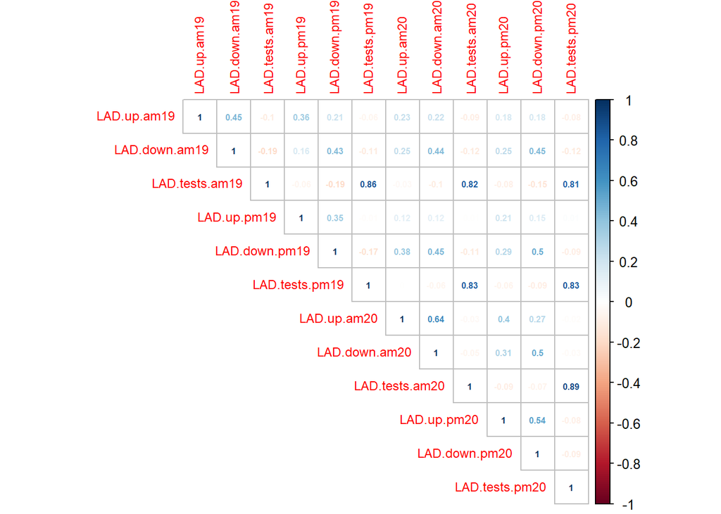

```r
data.cor <- data %>%
  dplyr::select(LAD.up.am19, LAD.down.am19,
                LAD.tests.am19, LAD.up.pm19,
                LAD.down.pm19, LAD.tests.pm19,
                LAD.up.am20, LAD.down.am20,
                LAD.tests.am20, LAD.up.pm20,
                LAD.down.pm20, LAD.tests.pm20)

m <- cor(data.cor)
corrplot(m, type="upper",method = "number", number.cex = .5, tl.cex = .75)
```

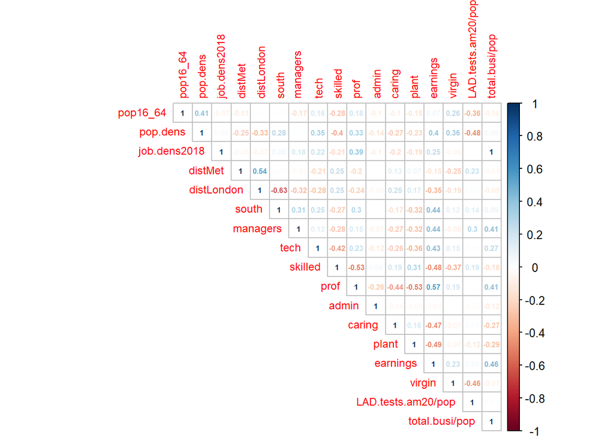

```r
data.cor <- data %>%
  dplyr::select(LAD.tests.am20,
                pop, pop16_64,
                managers, tech,
                skilled, earnings,
                total.busi)


data.cor <- data %>%
  dplyr::select(pop16_64,
                pop.dens,
                job.dens2018,
                distMet,
                distLondon,
                south,
                managers,
                tech,
                skilled,
                prof,
                admin,
                caring,
                plant,
                earnings,
                total.busi,
                LAD.tests.am20,
                pop,
                virgin) %>%
  mutate('LAD.tests.am20/pop' = LAD.tests.am20/pop) %>%
    mutate('total.busi/pop' = total.busi/pop) %>%
  dplyr::select(-LAD.tests.am20,-pop, -total.busi)


m <- cor(data.cor, use = "pairwise.complete.obs")
corrplot(m, type="upper",method = "number", number.cex = .5, tl.cex = .75)
```

```r
stargazer(data.cor,
          type="html",
          #type="text",
          summary = T,
          nobs = T)
```

| Statistic | N | Mean | St. Dev. | Min | Pctl(25) | Pctl(75) | Max |
| --- | --- | --- | --- | --- | --- | --- | --- |
| pop16_64 | 365 | 109,720.300 | 79,145.520 | 5,800 | 60,300 | 137,000 | 733,600 |
| pop.dens | 365 | 1,556.005 | 2,431.645 | 8.210 | 191.534 | 1,967.791 | 16,088.280 |
| job.dens2018 | 365 | 1.137 | 5.726 | 0.400 | 0.700 | 0.930 | 110.110 |
| distMet | 365 | 53.269 | 57.700 | 0.150 | 22.050 | 69.290 | 544.090 |
| distLondon | 365 | 201.558 | 173.634 | 0.150 | 76.180 | 278.880 | 1,003.950 |
| south | 365 | 0.463 | 0.499 | 0 | 0 | 1 | 1 |
| managers | 363 | 12.009 | 4.013 | 3.600 | 9.000 | 14.300 | 27.900 |
| tech | 364 | 14.505 | 4.057 | 3.500 | 11.800 | 16.900 | 29.600 |
| skilled | 358 | 10.513 | 3.764 | 1.000 | 8.025 | 12.500 | 21.600 |
| prof | 364 | 21.223 | 6.902 | 4.400 | 16.775 | 24.850 | 71.600 |
| admin | 359 | 9.965 | 2.738 | 3.200 | 8.100 | 11.400 | 21.300 |
| caring | 362 | 9.261 | 2.827 | 2.800 | 7.300 | 11.400 | 17.800 |
| plant | 337 | 6.339 | 2.847 | 1.200 | 4.400 | 7.900 | 19.800 |
| earnings | 360 | 592.184 | 81.129 | 437.600 | 534.625 | 633.875 | 893.200 |
| virgin | 365 | 0.152 | 0.141 | 0.000 | 0.018 | 0.241 | 0.753 |
| LAD.tests.am20/pop | 365 | 0.0005 | 0.0002 | 0.0001 | 0.0003 | 0.001 | 0.001 |
| total.busi/pop | 365 | 0.057 | 0.164 | 0.023 | 0.038 | 0.056 | 3.174 |

## Auxiliary regression, dep. var.: upload clusters

```r
# helpful sources: http://www.princeton.edu/~otorres/LogitR101.pdf
# https://thestatsgeek.com/2014/02/08/r-squared-in-logistic-regression/

# convert dependent variable to factor
data$cluster.up <- as.factor(data$cluster.up)
data$cluster.up <- relevel(data$cluster.up, "4") # base category: cluster 4

aux <- multinom(cluster.up ~
                  #pop16_64 + # non sign, while pop is
                  pop +
                  #pop.dens +
                  job.dens2018 + # pop.dens is still insignificant when job.dens is excluded
                  distMet + distLondon + south +
                  managers + tech + skilled + prof + admin + caring + plant +
                  earnings + I(total.busi/pop) + nvq4 +
                  I(LAD.tests.am20/pop) + # non sensitive to addition of other tests pm
                  virgin
                , data = data,
                trace = F) # to avoid messages

# McFadden's R squared
aux.null <- multinom(cluster.up ~ 1, data = data)
```

# weights: 26 (12 variable)

initial value 936.206515 iter 10 value 574.869248 iter 20 value 568.371708 final value 568.363400 converged

```r
r2 <- 1-logLik(aux)/logLik(aux.null)

n.obs <- dim(aux$fitted.values)[1]

stargazer(aux,
          type = "html",
          #type = "text",
          nobs = T,
          digits = 3,
          covariate.labels=c(#"pop. 16-64, 2018",
                             "pop, 2018",
                             #"pop. densuty, 2018",
                             "job density, 2018",
                             "distance to nearest met. area",
                             "distance to London",
                             "South of the UK",
                             "% of managerial jobs, 2020",
                             "% of tech jobs, 2020",
                             "% of skilled trade jobs, 2020",
                             "% of professional jobs, 2020",
                             "% of administrative jobs, 2020",
                             "% of leisure jobs, 2020",
                             "% of machine operation jobs, 2020",
                             "earnings, 2019",
                             "n. business est. per hab., 2019",
                             "% of NVQ4+",
                             "n. of AM broadband tests per hab., 2020",
                             "% of Virgin Media connections"),
          add.lines = list(c("McFadden's R squared",
                             round(r2[1],3), round(r2[1],3), round(r2[1],3),
                             round(r2[1],3), round(r2[1],3), round(r2[1],3),
                             round(r2[1],3), round(r2[1],3), round(r2[1],3)
                             , round(r2[1],3), round(r2[1],3)),
                           (c("N",
                            n.obs, n.obs, n.obs,
                            n.obs, n.obs, n.obs,
                            n.obs, n.obs, n.obs
                            , n.obs, n.obs))))
```

*Dependent variable:*

1

2

3

6

7

8

9

10

11

12

13

(1)

(2)

(3)

(4)

(5)

(6)

(7)

(8)

(9)

(10)

(11)

pop, 2018

-0.00004***

0.00002*

0.00001

0.00002***

0.00002***

0.00000

0.00002***

0.00002***

0.00002***

0.00002**

0.00002***

(0.00002)

(0.00001)

(0.00001)

(0.00001)

(0.00001)

(0.00002)

(0.00001)

(0.00001)

(0.00001)

(0.00001)

(0.00001)

job density, 2018

-0.536***

-1.834***

-0.132***

-0.925***

-1.208***

-0.299***

-1.746***

-1.436***

3.350***

3.400***

0.630***

(0.00000)

(0.00000)

(0.00000)

(0.00000)

(0.00000)

(0.00000)

(0.00000)

(0.00000)

(0.00000)

(0.00000)

(0.00000)

distance to nearest met. area

-0.034***

-0.014***

0.002***

-0.020***

-0.074***

-0.044***

-0.013***

-0.036***

-0.031***

-0.036***

-0.024***

(0.0005)

(0.001)

(0.0002)

(0.002)

(0.0001)

(0.0002)

(0.002)

(0.0005)

(0.0003)

(0.0002)

(0.002)

distance to London

0.007***

0.002

-0.016***

0.001

0.004***

0.004***

-0.002*

0.005**

-0.002

0.003

0.006***

(0.001)

(0.002)

(0.0004)

(0.001)

(0.001)

(0.001)

(0.001)

(0.002)

(0.002)

(0.002)

(0.001)

South of the UK

-0.410***

-1.451***

-0.039***

-0.111***

-0.048***

-0.841***

-0.798***

1.492***

0.610***

0.798***

2.403***

(0.00000)

(0.00000)

(0.00000)

(0.00001)

(0.00000)

(0.00000)

(0.00001)

(0.00000)

(0.00001)

(0.00001)

(0.00001)

% of managerial jobs, 2020

0.939***

0.704***

0.435***

0.704***

0.316***

0.786***

0.576***

0.311***

0.476***

0.594***

0.615***

(0.00004)

(0.0001)

(0.00004)

(0.00004)

(0.00002)

(0.0001)

(0.00003)

(0.00003)

(0.00002)

(0.00004)

(0.00003)

% of tech jobs, 2020

0.096***

-0.257***

-0.071***

-0.111***

-0.206***

0.199***

-0.126***

-0.606***

-0.180***

-0.398***

-0.112***

(0.00004)

(0.00004)

(0.00004)

(0.00003)

(0.00003)

(0.0001)

(0.00003)

(0.00003)

(0.00002)

(0.00004)

(0.00003)

% of skilled trade jobs, 2020

0.651***

0.160***

-0.191***

0.236***

0.604***

-0.184***

0.205***

0.597***

0.108***

-0.022***

0.295***

(0.00004)

(0.00004)

(0.00003)

(0.00003)

(0.00003)

(0.00004)

(0.00002)

(0.00003)

(0.00003)

(0.00004)

(0.00003)

% of professional jobs, 2020

-0.118***

-0.234***

-0.121***

-0.172***

-0.514***

-0.172***

-0.349***

-0.351***

-0.245***

-0.344***

-0.229***

(0.00005)

(0.0001)

(0.0001)

(0.00005)

(0.00003)

(0.0001)

(0.00004)

(0.0001)

(0.00003)

(0.00005)

(0.0001)

% of administrative jobs, 2020

0.019***

-0.836***

-0.040***

-0.117***

-0.139***

0.206***

-0.058***

-0.200***

-0.055***

-0.168***

-0.177***

(0.00003)

(0.00002)

(0.00004)

(0.00001)

(0.00003)

(0.00003)

(0.00001)

(0.00002)

(0.00002)

(0.00002)

(0.00002)

% of leisure jobs, 2020

-0.198***

-0.180***

-0.225***

-0.476***

-0.654***

-0.820***

-0.537***

-0.935***

-0.353***

-0.625***

-0.491***

(0.00002)

(0.00004)

(0.00004)

(0.00002)

(0.00002)

(0.00003)

(0.00002)

(0.00001)

(0.00002)

(0.00003)

(0.00002)

% of machine operation jobs, 2020

-0.336***

0.207***

0.392***

0.010***

-0.433***

0.139***

-0.099***

-0.139***

-0.144***

0.098***

-0.179***

(0.00002)

(0.00003)

(0.00003)

(0.00002)

(0.00001)

(0.00003)

(0.00002)

(0.00001)

(0.00001)

(0.00002)

(0.00001)

earnings, 2019

-0.003*

0.010***

0.012***

0.020***

0.027***

0.001

0.020***

0.016***

0.015***

0.025***

0.014***

(0.002)

(0.002)

(0.002)

(0.001)

(0.001)

(0.003)

(0.001)

(0.002)

(0.001)

(0.001)

(0.001)

14. business est. per hab., 2019

0.126***

-0.120***

-0.094***

-0.133***

0.123***

-0.051***

-0.334***

-0.133***

-0.150***

0.289***

0.377***

(0.00000)

(0.00000)

(0.00000)

(0.00000)

(0.00000)

(0.00000)

(0.00000)

(0.00000)

(0.00000)

(0.00000)

(0.00000)

% of NVQ4+

-0.141***

0.064***

-0.091***

-0.070***

-0.010***

0.004***

0.016***

0.170***

-0.110***

-0.038***

-0.035***

(0.0001)

(0.0001)

(0.0001)

(0.0001)

(0.0001)

(0.0002)

(0.0001)

(0.0001)

(0.0001)

(0.0001)

(0.0001)

14. of AM broadband tests per hab., 2020

0.0005***

-0.002***

-0.005***

0.010***

0.0004***

-0.001***

-0.002***

-0.005***

-0.013***

-0.001***

0.016***

(0.000)

(0.000)

(0.000)

(0.000)

(0.000)

(0.000)

(0.000)

(0.000)

(0.000)

(0.000)

(0.000)

% of Virgin Media connections

-0.044***

1.578***

1.210***

0.248***

-1.724***

-0.242***

3.109***

-0.085***

1.214***

-3.889***

-0.745***

(0.00000)

(0.00000)

(0.00000)

(0.00000)

(0.00000)

(0.00000)

(0.00000)

(0.00000)

(0.00000)

(0.00000)

(0.00000)

Constant

0.321***

-0.436***

0.199***

-2.953***

0.278***

0.002***

-0.866***

0.788***

2.600***

0.017***

0.022***

(0.00000)

(0.00000)

(0.00000)

(0.00000)

(0.00000)

(0.00000)

(0.00000)

(0.00000)

(0.00000)

(0.00000)

(0.00000)

McFadden’s R squared

0.338

0.338

0.338

0.338

0.338

0.338

0.338

0.338

0.338

0.338

0.338

N

323

323

323

323

323

323

323

323

323

323

323

Akaike Inf. Crit.

1,148.027

1,148.027

1,148.027

1,148.027

1,148.027

1,148.027

1,148.027

1,148.027

1,148.027

1,148.027

1,148.027

*Note:*

p<0.1; p<0.05; p<0.01

## Auxiliary regression, dep. var.: test clusters

```r
# helpful sources: http://www.princeton.edu/~otorres/LogitR101.pdf
# https://thestatsgeek.com/2014/02/08/r-squared-in-logistic-regression/

# convert dependent variable to factor
data$cluster.tests <- as.factor(data$cluster.tests)
data$cluster.tests <- relevel(data$cluster.tests, "4") # base category

aux <- multinom(cluster.tests ~
                  #pop16_64 + # non sign, while pop is
                  pop +
                  #pop.dens +
                  job.dens2018 + # pop.dens is still insignificant when job.dens is excluded
                  distMet + distLondon + south + nvq4 +
                  managers + tech + skilled + prof + admin + caring + plant +
                  earnings + I(total.busi/pop) +
                  I(LAD.tests.am20/pop) + # non sensitive to addition of other tests pm
                  virgin
                , data = data,
                trace = F) # to avoid messages

# McFadden's R squared
aux.null <- multinom(cluster.tests ~ 1, data = data)
```

# weights: 14 (6 variable)

initial value 710.257204 iter 10 value 662.329927 final value 662.328134 converged

```r
r2 <- 1-logLik(aux)/logLik(aux.null)

n.obs <- dim(aux$fitted.values)[1]

stargazer(aux,
          type = "html",
          #type = "text",
          digits = 3,
          covariate.labels=c(#"pop. 16-64, 2018",
                             "pop, 2018",
                             #"pop. densuty, 2018",
                             "job density, 2018",
                             "distance to nearest met. area",
                             "distance to London",
                             "South of the UK",
                             "% of managerial jobs, 2020",
                             "% of tech jobs, 2020",
                             "% of skilled trade jobs, 2020",
                             "% of professional jobs, 2020",
                             "% of administrative jobs, 2020",
                             "% of leisure jobs, 2020",
                             "% of machine operation jobs, 2020",
                             "earnings, 2019",
                             "n. business est. per hab., 2019",
                             "% of NVQ4+",
                             "n. of AM broadband tests per hab., 2020",
                             "% of Virgin Media connections"),
          add.lines = list(c("McFadden's R squared",
                             round(r2[1],3), round(r2[1],3), round(r2[1],3),
                             round(r2[1],3), round(r2[1],3), round(r2[1],3)),
                           (c("N",
                            n.obs, n.obs, n.obs,
                            n.obs, n.obs, n.obs))))
```

*Dependent variable:*

1

2

3

5

6

7

(1)

(2)

(3)

(4)

(5)

(6)

pop, 2018

-0.00003***

0.00000

-0.00001

0.00001***

0.0001***

0.00002***

(0.00000)

(0.00000)

(0.00000)

(0.00000)

(0.00001)

(0.00000)

job density, 2018

0.346***

-0.154***

-0.200***

-0.669***

-9.284***

-0.546***

(0.00000)

(0.00000)

(0.00000)

(0.00000)

(0.00001)

(0.00000)

distance to nearest met. area

0.005*

0.011***

-0.001***

0.006*

-0.002***

0.012***

(0.003)

(0.003)

(0.0004)

(0.003)

(0.001)

(0.003)

distance to London

-0.0001

0.001

-0.001

0.001

0.010***

0.004***

(0.001)

(0.001)

(0.002)

(0.001)

(0.004)

(0.002)

South of the UK

0.208***

1.375***

0.334***

1.052***

0.124***

2.022***

(0.00001)

(0.00001)

(0.00000)

(0.00001)

(0.00001)

(0.00001)

% of managerial jobs, 2020

-0.071***

-0.042***

-0.040***

-0.031***

0.331***

-0.068***

(0.0001)

(0.0001)

(0.0001)

(0.0001)

(0.0003)

(0.0001)

% of tech jobs, 2020

-0.068***

0.028***

0.098***

0.124***

0.435***

0.296***

(0.00004)

(0.00004)

(0.00004)

(0.00003)

(0.0001)

(0.00004)

% of skilled trade jobs, 2020

-0.024***

0.068***

0.020***

0.084***

-0.829***

0.224***

(0.00004)

(0.00004)

(0.00003)

(0.00004)

(0.0001)

(0.00004)

% of professional jobs, 2020

-0.150***

-0.102***

-0.076***

0.015***

-0.183***

0.195***

(0.00004)

(0.00004)

(0.00003)

(0.0001)

(0.00005)

(0.00003)

% of administrative jobs, 2020

-0.032***

0.051***

-0.049***

0.106***

-0.478***

0.297***

(0.0001)

(0.0001)

(0.00004)

(0.0001)

(0.0001)

(0.0001)

% of leisure jobs, 2020

-0.028***

0.228***

-0.006***

0.112***

-0.276***

0.362***

(0.00001)

(0.00003)

(0.00002)

(0.00003)

(0.00005)

(0.00002)

% of machine operation jobs, 2020

-0.067***

0.155***

-0.045***

0.147***

0.436***

0.187***

(0.00001)

(0.00003)

(0.00002)

(0.0001)

(0.00004)

(0.00003)

earnings, 2019

0.061***

0.017***

-0.062***

0.026***

0.078***

0.196***

(0.00001)

(0.00001)

(0.00001)

(0.00003)

(0.00002)

(0.00002)

14. business est. per hab., 2019

0.001

0.0002

-0.004***

-0.006***

0.024***

-0.008***

(0.001)

(0.001)

(0.001)

(0.001)

(0.004)

(0.001)

% of NVQ4+

4.843***

-7.980***

2.801***

-0.816***

3.361***

0.425***

(0.00000)

(0.00000)

(0.00000)

(0.00000)

(0.00000)

(0.00000)

14. of AM broadband tests per hab., 2020

-1.325***

0.002***

-0.005***

0.674***

0.217***

1.248***

(0.000)

(0.000)

(0.000)

(0.000)

(0.000)

(0.000)

% of Virgin Media connections

4.106***

-2.783***

-2.617***

-3.251***

-66.449***

-9.361***

(0.00000)

(0.00000)

(0.00000)

(0.00000)

(0.00000)

(0.00000)

Constant

8.798***

-4.426***

6.314***

-3.702***

-22.819***

-19.274***

(0.00000)

(0.00000)

(0.00000)

(0.00000)

(0.00000)

(0.00000)

McFadden’s R squared

0.364

0.364

0.364

0.364

0.364

0.364

N

323

323

323

323

323

323

Akaike Inf. Crit.

1,057.856

1,057.856

1,057.856

1,057.856

1,057.856

1,057.856

*Note:*

p<0.1; p<0.05; p<0.01

## Auxiliary regression, dep. var.: down clusters

```r
# helpful sources: http://www.princeton.edu/~otorres/LogitR101.pdf
# https://thestatsgeek.com/2014/02/08/r-squared-in-logistic-regression/

# convert dependent variable to factor
data$cluster.down <- as.factor(data$cluster.down)
data$cluster.down <- relevel(data$cluster.down, "2") # base category

aux <- multinom(cluster.down ~
                  #pop16_64 + # non sign, while pop is
                  pop +
                  #pop.dens +
                  job.dens2018 + # pop.dens is still insignificant when job.dens is excluded
                  distMet + distLondon + south +
                  managers + tech + skilled + prof + admin + caring + plant +
                  earnings + I(total.busi/pop) + nvq4 +
                  I(LAD.tests.am20/pop) + # non sensitive to addition of other tests pm
                  virgin
                , data = data,
                trace = F) # to avoid messages

# McFadden's R squared
aux.null <- multinom(cluster.down ~ 1, data = data)
```

# weights: 20 (9 variable)

initial value 840.443559 iter 10 value 570.635850 iter 20 value 564.809863 iter 20 value 564.809863 final value 564.809863 converged

```r
r2 <- 1-logLik(aux)/logLik(aux.null)

n.obs <- dim(aux$fitted.values)[1]

stargazer(aux,
          type = "html",
          #type = "text",
          digits = 3,
          covariate.labels=c(#"pop. 16-64, 2018",
                             "pop, 2018",
                             #"pop. densuty, 2018",
                             "job density, 2018",
                             "distance to nearest met. area",
                             "distance to London",
                             "South of the UK",
                             "% of managerial jobs, 2020",
                             "% of tech jobs, 2020",
                             "% of skilled trade jobs, 2020",
                             "% of professional jobs, 2020",
                             "% of administrative jobs, 2020",
                             "% of leisure jobs, 2020",
                             "% of machine operation jobs, 2020",
                             "earnings, 2019",
                             "n. business est. per hab., 2019",
                             "% of NVQ4+",
                             "n. of AM broadband tests per hab., 2020",
                             "% of Virgin Media connections"),
          add.lines = list(c("McFadden's R squared",
                             round(r2[1],3), round(r2[1],3), round(r2[1],3),
                             round(r2[1],3), round(r2[1],3), round(r2[1],3),
                             round(r2[1],3), round(r2[1],3), round(r2[1],3),
                             round(r2[1],3), round(r2[1],3), round(r2[1],3),
                             round(r2[1],3), round(r2[1],3), round(r2[1],3),
                             round(r2[1],3), round(r2[1],3), round(r2[1],3),
                             round(r2[1],3)),
                           (c("N",
                            n.obs, n.obs, n.obs,
                            n.obs, n.obs, n.obs,
                            n.obs, n.obs, n.obs,
                            n.obs, n.obs, n.obs,
                            n.obs, n.obs, n.obs,
                            n.obs, n.obs, n.obs,
                            n.obs))))
```

*Dependent variable:*

1

3

4

5

6

7

8

9

10

(1)

(2)

(3)

(4)

(5)

(6)

(7)

(8)

(9)

pop, 2018

-0.00002***

-0.00001

-0.00002***

-0.00000

-0.00000

-0.00000

-0.00001

0.00000

-0.00002*

(0.00001)

(0.00001)

(0.00001)

(0.00000)

(0.00000)

(0.00000)

(0.00001)

(0.00000)

(0.00001)

job density, 2018

-1.885***

1.560***

0.101***

0.287***

-0.811***

1.476***

0.072***

0.374***

-0.997***

(0.00000)

(0.00000)

(0.00000)

(0.00000)

(0.00000)

(0.00000)

(0.00000)

(0.00000)

(0.00000)

distance to nearest met. area

-0.003

0.007***

0.003

-0.008***

-0.006**

0.001

-0.013***

-0.002

-0.041***

(0.003)

(0.001)

(0.002)

(0.0003)

(0.002)

(0.003)

(0.0003)

(0.003)

(0.0001)

distance to London

0.006***

0.001

0.005***

-0.001

0.006***

-0.002

0.012***

0.001

-0.002***

(0.001)

(0.003)

(0.002)

(0.002)

(0.001)

(0.001)

(0.002)

(0.001)

(0.001)

South of the UK

1.985***

-0.152***

-0.954***

0.903***

0.831***

-0.800***

0.753***

-0.489***

-0.230***

(0.00001)

(0.00001)

(0.00001)

(0.00001)

(0.00001)

(0.00001)

(0.00000)

(0.00001)

(0.00000)

% of managerial jobs, 2020

0.114***

0.011***

-0.022***

-0.018***

0.110***

-0.076***

0.166***

-0.040***

-0.138***

(0.00005)

(0.0001)

(0.0001)

(0.00003)

(0.00002)

(0.00002)

(0.0001)

(0.00002)

(0.00003)

% of tech jobs, 2020

0.245***

-0.025***

0.291***

0.215***

0.300***

0.069***

0.344***

0.026***

0.094***

(0.00005)

(0.00004)

(0.00005)

(0.00003)

(0.00002)

(0.00002)

(0.0001)

(0.00002)

(0.00004)

% of skilled trade jobs, 2020

0.306***

0.114***

0.001***

0.330***

0.310***

0.116***

0.134***

0.206***

0.208***

(0.00003)

(0.00004)

(0.00002)

(0.00005)

(0.00003)

(0.00002)

(0.00002)

(0.00002)

(0.00004)

% of professional jobs, 2020

0.119***

0.250***

0.253***

-0.080***

0.185***

-0.037***

0.002***

-0.032***

0.189***

(0.0001)

(0.0001)

(0.0001)

(0.00005)

(0.00005)

(0.00004)

(0.0001)

(0.00003)

(0.0001)

% of administrative jobs, 2020

0.203***

-0.051***

0.108***

0.064***

0.307***

0.179***

0.211***

0.085***

0.028***

(0.00003)

(0.00003)

(0.00002)

(0.00002)

(0.00003)

(0.00002)

(0.00002)

(0.00002)

(0.00004)

% of leisure jobs, 2020

0.028***

0.122***

0.206***

-0.032***

0.021***

-0.115***

-0.530***

0.098***

0.090***

(0.00002)

(0.00004)

(0.00002)

(0.00003)

(0.00003)

(0.00002)

(0.00002)

(0.00002)

(0.00003)

% of machine operation jobs, 2020

-0.410***

-0.576***

-0.814***

-0.317***

-0.428***

-0.647***

-0.338***

-0.741***

-0.293***

(0.00001)

(0.00002)

(0.00001)

(0.00003)

(0.00002)

(0.00002)

(0.00002)

(0.00002)

(0.00003)

earnings, 2019

-0.0004

0.003

0.015***

0.004***

0.008***

0.012***

0.003*

0.018***

0.013***

(0.001)

(0.002)

(0.002)

(0.001)

(0.001)

(0.001)

(0.002)

(0.001)

(0.002)

14. business est. per hab., 2019

0.120***

-0.073***

0.318***

-0.281***

-0.460***

0.233***

-0.042***

-0.111***

0.195***

(0.00000)

(0.00000)

(0.00000)

(0.00000)

(0.00000)

(0.00000)

(0.00000)

(0.00000)

(0.00000)

% of NVQ4+

-0.135***

-0.136***

-0.281***

-0.028***

-0.201***

-0.148***

-0.149***

-0.136***

-0.148***

(0.0001)

(0.0002)

(0.0002)

(0.0001)

(0.0001)

(0.0001)

(0.0001)

(0.0001)

(0.0001)

14. of AM broadband tests per hab., 2020

0.008***

-0.001***

-0.012***

-0.017***

0.030***

-0.011***

-0.001***

0.005***

-0.002***

(0.000)

(0.000)

(0.000)

(0.000)

(0.000)

(0.000)

(0.000)

(0.000)

(0.000)

% of Virgin Media connections

-13.951***

0.742***

-2.258***

1.307***

-9.488***

9.068***

0.273***

10.806***

2.624***

(0.00000)

(0.00000)

(0.00000)

(0.00000)

(0.00000)

(0.00000)

(0.00000)

(0.00000)

(0.00000)

Constant

3.539***

0.176***

0.348***

-0.523***

-3.177***

3.356***

-0.155***

-2.983***

-0.766***

(0.00000)

(0.00000)

(0.00000)

(0.00000)

(0.00000)

(0.00000)

(0.00000)

(0.00000)

(0.00000)

McFadden’s R squared

0.445

0.445

0.445

0.445

0.445

0.445

0.445

0.445

0.445

N

323

323

323

323

323

323

323

323

323

Akaike Inf. Crit.

950.988

950.988

950.988

950.988

950.988

950.988

950.988

950.988

950.988

*Note:*

p<0.1; p<0.05; p<0.01